# Project 2 | Phase 2

Michał Frej, Karolina Gajewska, Agnieszka Sitko, Marcin Wojno

## Introduction - dependent variable

In this project we analize data about the length of dendritic spines of mice and its dependence on genotype and five selected types of treatment (including no treatment as a one type).

Looking at QQ plots of `length` and `log(length)` we have decided to apply logarithmic transformation to the dependent variable, as it provides a distribution closer to normal.

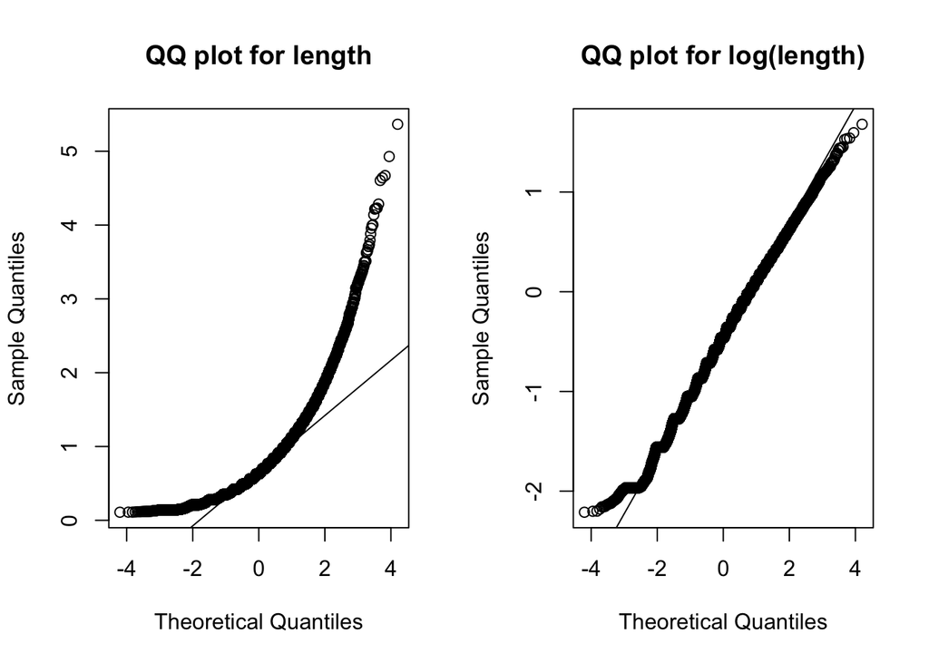

## Variables selection

### Mouse type

The following boxplot shows that there are differences in `log(length)` between mouse types.

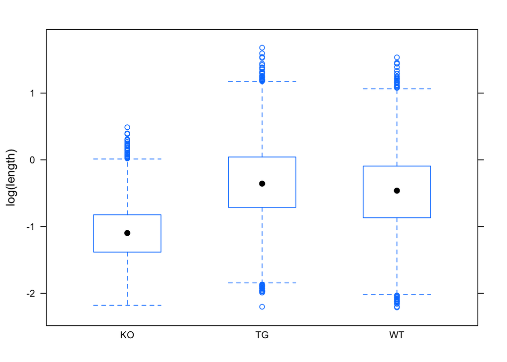

As we have stated in the beginning, we are interested in an influence of mouse genotype on the length of dendritic spines. Thus, we add `mouse` to our model as a fixed effect.

### Treatment

`log(length)` differs among treatment types (see boxplot below).

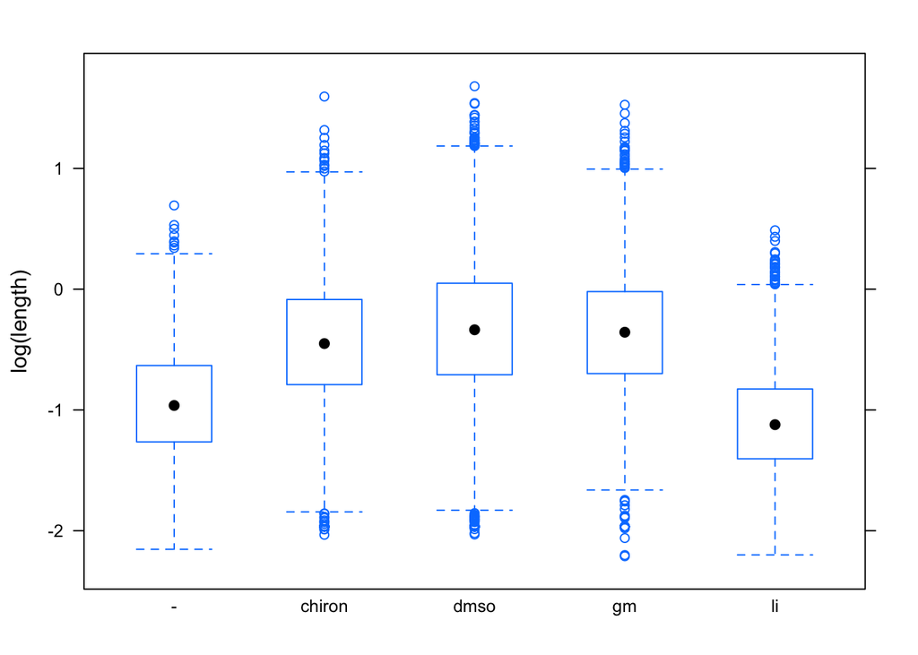

Following the same argumentation, we include `treatment` as a fixed effect.

### Interaction between mouse type and treatment

Using the results from the previous phase, we have decided to add interactions between `mouse` and `treatment` to the model. In the first phase we detected significant effect of such interactions in KO study.

### Animal:Photo_ID_abs

In the dataset variable `Photo_ID_abs` is naturally nested in `Animal` and `Animal` is nested in `Study`.

We cannot exclude from the model `Animal` and `Photo_ID_abs` effects, but, as we are not so interested in an impact of a particular photo or individual, we assume they are random.

### Study

Data may be groupped by study. Each study contains information collected for two out of three types of mouse and for two out of five types of treatment (including no treatment). Number of observations by study, mouse type and treatment are gathered in a table below.

```
##           chiron   gm   ko
## KO:-           0    0 1500
## KO:chiron      0    0    0
## KO:dmso        0    0    0
## KO:gm          0    0    0
## KO:li          0    0 1566
## TG:-           0    0    0
## TG:chiron   3249    0    0
## TG:dmso     3677 4471    0
## TG:gm          0 4762    0
## TG:li          0    0    0
## WT:-           0    0 1416
## WT:chiron   2909    0    0
## WT:dmso     3119 4451    0
## WT:gm          0 5032    0
## WT:li          0    0 2030
```

As we analyze all three studies (which could have been performed independently), we cannot exclude from our model study effect. The following boxplot gives more reasons to include this effect to the model - dendritic spines of mice from KO study are on average shorter than dendritic spines of mice from other studies.

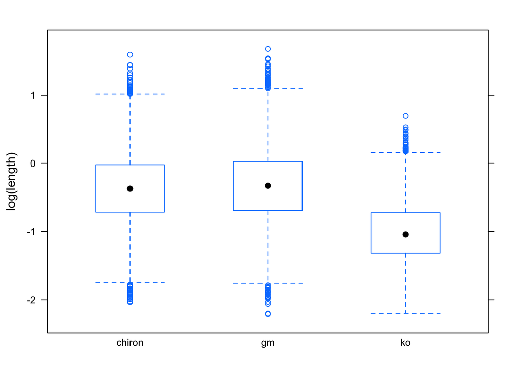

However, we are not interested in a effect of a particular study. Therefore, we include `Study` as a random variable.

We also check if the relation between the fixed variables introduced above and the dependent variable differs between studies.

## Creating the model

After those analysis, we can finally run a model. We start with a small model defined by a formula `log(length) ~ mouse + treatment + (mouse + treatment|Study)` (called `addMouseTreatGroupedByStudy`)

`addMouseTreatGroupedByStudy: log(length) ~ mouse + treatment + (mouse + treatment|Study)`

Now we add interaction between `mouse` and `treatment` to the model and check if it is significant.

`multiMouseTreat_noREML: log(length) ~ mouse * treatment + (mouse * treatment|Study)`

```r
anova(addMouseTreat_noREML, multiMouseTreat_noREML)
```

```
## Data: dendriticSpines
## Models:
## addMouseTreat_noREML: log(length) ~ mouse + treatment + (mouse + treatment | Study)
## multiMouseTreat_noREML: log(length) ~ mouse * treatment + (mouse * treatment | Study)
##                         Df   AIC   BIC logLik deviance  Chisq Chi Df
## addMouseTreat_noREML    36 56199 56507 -28064    56127
## multiMouseTreat_noREML 131 56315 57435 -28026    56053 74.573     95
##                        Pr(>Chisq)
## addMouseTreat_noREML
## multiMouseTreat_noREML       0.94
```

It turns out that interaction can be ignored, because p.value is high.

`additiveAnimal_noREML: log(length) ~ mouse + treatment + (mouse + treatment|Study) + (1|Study/Animal)`

Next, we include a random varable `Study/Animal` into the model.

```r
anova(addMouseTreat_noREML, additiveAnimal_noREML)
```

```
## Data: dendriticSpines
## Models:
## addMouseTreat_noREML: log(length) ~ mouse + treatment + (mouse + treatment | Study)
## additiveAnimal_noREML: log(length) ~ mouse + treatment + (mouse + treatment | Study) +
## additiveAnimal_noREML:     (1 | Study/Animal)
##                       Df   AIC   BIC logLik deviance  Chisq Chi Df
## addMouseTreat_noREML  36 56199 56507 -28064    56127
## additiveAnimal_noREML 38 55724 56049 -27824    55648 479.59      2
##                       Pr(>Chisq)
## addMouseTreat_noREML
## additiveAnimal_noREML  < 2.2e-16 ***
## ---
## Signif. codes:  0 '***' 0.001 '**' 0.01 '*' 0.05 '.' 0.1 ' ' 1
```

So adding this variable improves the model significantly.

`PhotoadditiveMouseTreat_noREML: log(length) ~ mouse + treatment + (mouse + treatment|Study) + (1|Study/Animal/Photo_ID_abs)`

Finally, we add a random variable `Study/Animal/Photo_ID_abs`.

```r
anova(additiveAnimal_noREML, PhotoadditiveMouseTreat_noREML)
```

```
## Data: dendriticSpines
## Models:
## additiveAnimal_noREML: log(length) ~ mouse + treatment + (mouse + treatment | Study) +
## additiveAnimal_noREML:     (1 | Study/Animal)
## PhotoadditiveMouseTreat_noREML: log(length) ~ mouse + treatment + (mouse + treatment | Study) +
## PhotoadditiveMouseTreat_noREML:     (1 | Study/Animal/Photo_ID_abs)
##                                Df   AIC   BIC logLik deviance  Chisq
## additiveAnimal_noREML          38 55724 56049 -27824    55648
## PhotoadditiveMouseTreat_noREML 39 54818 55151 -27370    54740 907.96
##                                Chi Df Pr(>Chisq)
## additiveAnimal_noREML
## PhotoadditiveMouseTreat_noREML      1  < 2.2e-16 ***
## ---
## Signif. codes:  0 '***' 0.001 '**' 0.01 '*' 0.05 '.' 0.1 ' ' 1
```

So adding this variable improves the model significantly.

## Model diagnostics

Which fixed effects are important?

```r
bestModel <- PhotoadditiveMouseTreat_noREML_final
tStat <- summary(bestModel)$coeff[,3]
pValues <- sapply(1:length(tStat),function(i) {2*pnorm(abs(tStat[i]),lower.tail = F)})
pValues
```

```
##     (Intercept)         mouseTG         mouseWT treatmentchiron
##   1.257945e-145    9.397630e-03    9.127905e-03    2.229137e-22
##   treatmentdmso     treatmentgm     treatmentli
##    1.159148e-34    1.510130e-29    2.195478e-04
```

Is variance homogeneous in different groups? Yes it is.

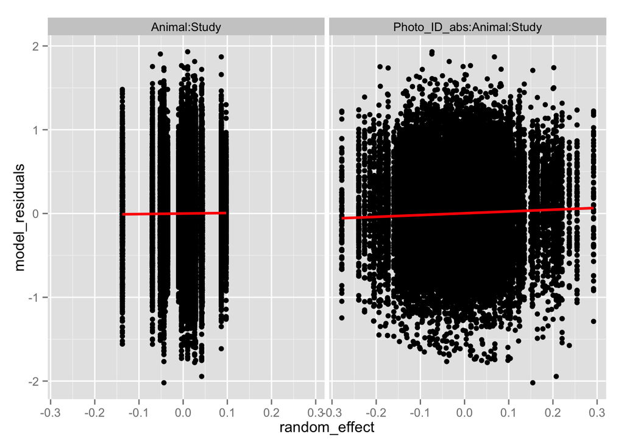

```r
u <- ranef(bestModel, condVar = TRUE)
e <- residuals(bestModel)

# w contains a 'nested' random effect for Animal
w <- u$`Animal:Study`[paste0(dendriticSpines$Animal,":",dendriticSpines$Study),1]

# x contains a 'nested' random effect for Photo
x <- u$`Photo_ID_abs:(Animal:Study)`[paste0(dendriticSpines$Photo_ID_abs,":",dendriticSpines$Animal,":",dendriticSpines$Study),1]

d <- data.frame(model_residuals=c(e,e), random_effect=c(w,x),
                type=rep(c("Animal:Study", "Photo_ID_abs:Animal:Study"), each=nrow(dendriticSpines)))
ggplot(d, aes(x=random_effect, y=model_residuals)) + geom_point() + geom_smooth(method="lm", col="red", size=1)+
  facet_wrap(~type)
```

Let’s look at residuals of our model.

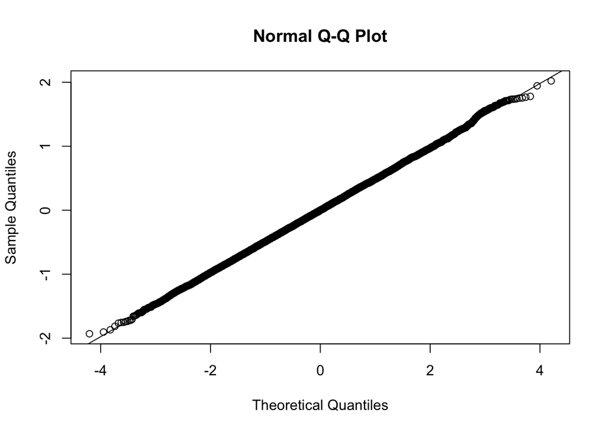

```r
residuals <- fitted.values(bestModel) - log(length)
qqnorm(residuals)
qqline(residuals)
```

The plot is really good. The following normality test confirms as well, that the residuals follow the normal distribution. We have over 38k residuals, so we can’t use ks.test. In library nortest there is function lillie.test, which performs the Lilliefors(Kolmogorov-Smirnov) test for normality.

```r
lillie.test(residuals)
```

```
##
##  Lilliefors (Kolmogorov-Smirnov) normality test
##
## data:  residuals
## D = 0.0041587, p-value = 0.113
```

So residuals are normally distributed.

### Random effects

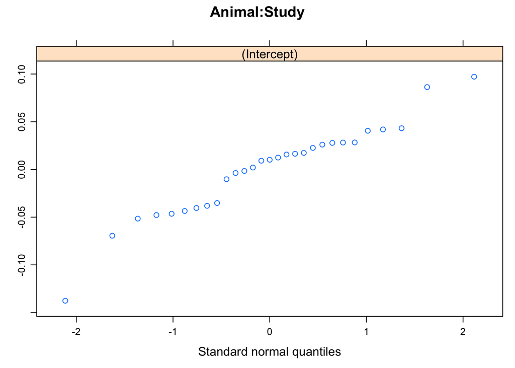

```r
u <- ranef(bestModel,condVar=T)
qqmath(u)$`Animal:Study`
```

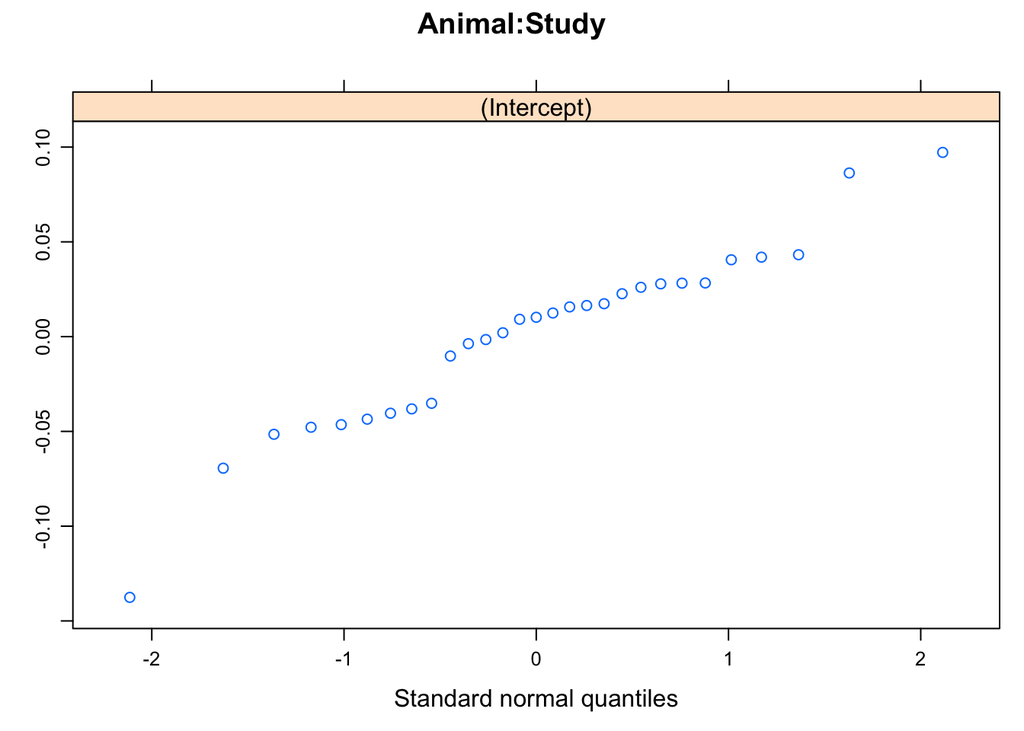

```r
qqmath(u)[[2]]
```

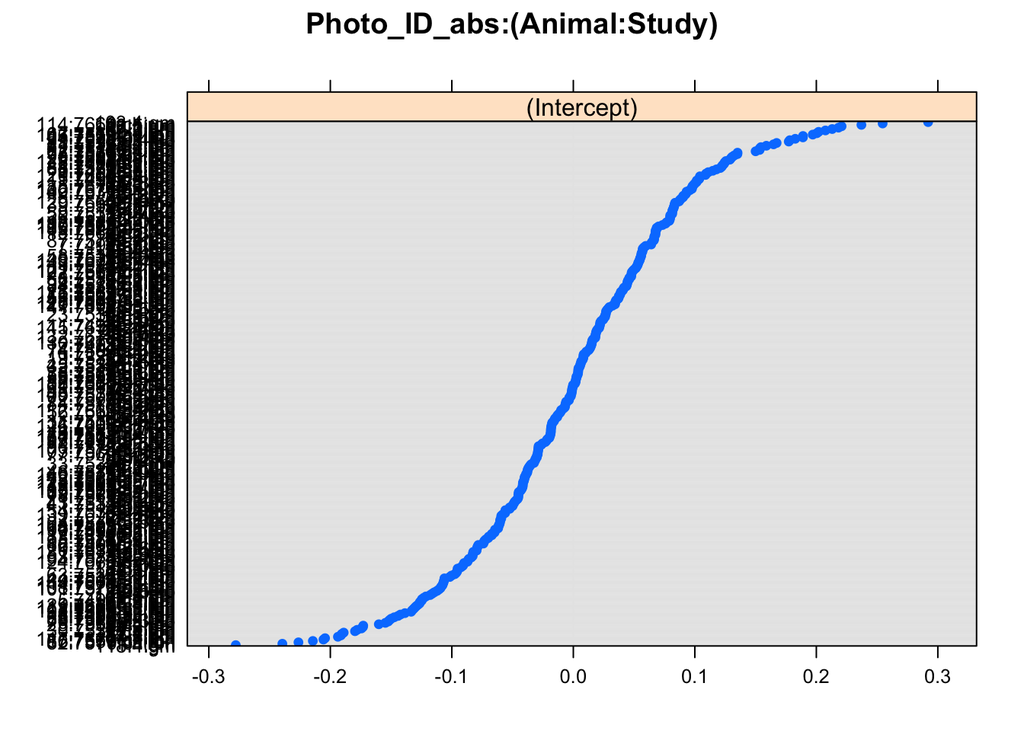

```r
dotplot(u)$`Photo_ID_abs:(Animal:Study)`
```

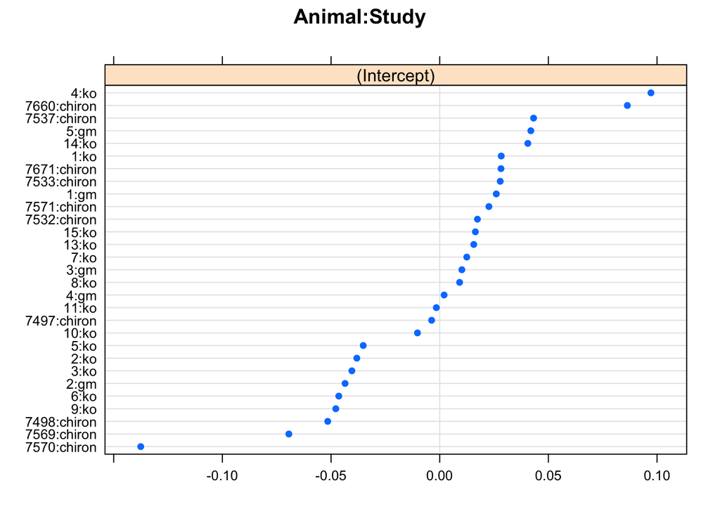

```r
dotplot(u)$`Animal:Study`
```

### Conclusions

We picked mouse treatent as fixed effects grouped by Study and animal, photo as random. All the effects were significant. Interactions were not significant.

### Literature

#### [1] Modele liniowe z efektami sta??ymi, losowymi i mieszanymi. P. Biecek

#### [2] www.google.com